# Tugas Pertemuan 2

Muhammad Fauzan Nur Rasendriya (G1401231108)

02 September 2025

# Data

## Impor Data

```r
url <- "https://raw.githubusercontent.com/fauzanrasendriya/MPDW/main/Pertemuan%202/dataudarajkt.csv"
data <- import(url)

# filter baris 251 sampai 375
subset_data <- data[251:375, ]

# menampilkan 5 data pertama
head(subset_data)
```

|  | tanggal | stasiun | pm25 | pm10 | so2 | co | o3 | no2 | max | critical | categori |
| --- | --- | --- | --- | --- | --- | --- | --- | --- | --- | --- | --- |
| 251 | 2024-06-24 | DKI1 (Bunderan HI) | 85 | 57 | 15 | 26 | 20 | 40 | 85 | PM25 | SEDANG |
| 252 | 2024-06-25 | DKI1 (Bunderan HI) | 76 | 58 | 20 | 26 | 20 | 34 | 76 | PM25 | SEDANG |
| 253 | 2024-06-26 | DKI1 (Bunderan HI) | 65 | 51 | 13 | 30 | 23 | 29 | 65 | PM25 | SEDANG |
| 254 | 2024-06-27 | DKI1 (Bunderan HI) | 74 | 56 | 14 | 25 | 23 | 32 | 74 | PM25 | SEDANG |
| 255 | 2024-06-28 | DKI1 (Bunderan HI) | 67 | 53 | 12 | 27 | 24 | 33 | 67 | PM25 | SEDANG |
| 256 | 2024-06-29 | DKI1 (Bunderan HI) | 74 | 52 | 11 | 34 | 22 | 34 | 74 | PM25 | SEDANG |

## Eksplorasi Data

```r
# lihat data
View(subset_data)
str(subset_data)
```

```
## 'data.frame':    125 obs. of  11 variables:
##  $ tanggal : IDate, format: "2024-06-24" "2024-06-25" ...
##  $ stasiun : chr  "DKI1 (Bunderan HI)" "DKI1 (Bunderan HI)" "DKI1 (Bunderan HI)" "DKI1 (Bunderan HI)" ...
##  $ pm25    : int  85 76 65 74 67 74 58 90 74 103 ...
##  $ pm10    : int  57 58 51 56 53 52 41 62 55 69 ...
##  $ so2     : int  15 20 13 14 12 11 10 11 9 12 ...
##  $ co      : int  26 26 30 25 27 34 24 28 26 38 ...
##  $ o3      : int  20 20 23 23 24 22 23 31 25 29 ...
##  $ no2     : int  40 34 29 32 33 34 33 41 38 51 ...
##  $ max     : int  85 76 65 74 67 74 58 90 74 103 ...
##  $ critical: chr  "PM25" "PM25" "PM25" "PM25" ...
##  $ categori: chr  "SEDANG" "SEDANG" "SEDANG" "SEDANG" ...
```

```r
dim(subset_data)
```

```
## [1] 125  11
```

```r
# pilih variabel
target_col <- "pm10"

# buat time series
ts_data <- ts(subset_data[[target_col]], frequency = 1)

# ringkasan data
summary(ts_data)
```

```
##    Min. 1st Qu.  Median    Mean 3rd Qu.    Max.
##   24.00   55.00   59.00   57.84   62.00   75.00
```

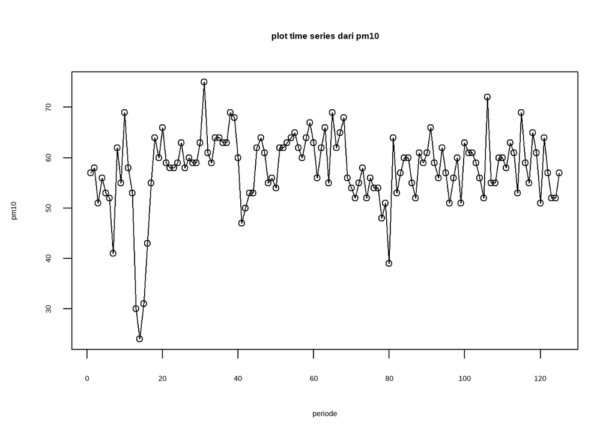

```r
# plot time series
ts.plot(ts_data, xlab="periode", ylab=target_col,
        main = paste("plot time series dari", target_col))
points(ts_data)
```

```r
# menyimpan plot
dev.copy(png, paste0("plot_", target_col, ".png"))
```

```r
dev.off()
```

## Pembagian Data Latih / Uji

Pembagian data latih dan data uji dilakukan dengan perbandingan 80% data latih dan 20% data uji.

```r
# hitung jumlah data
n <- nrow(subset_data)

# tentukan batas 80%
n_train <- floor(0.8 * n)

# bagi data
training_ts <- subset_data[1:n_train, ]
testing_ts  <- subset_data[(n_train+1):n, ]

# ubah ke time series pakai target_col
train.ts <- ts(training_ts[[target_col]])
test.ts  <- ts(testing_ts[[target_col]])
```

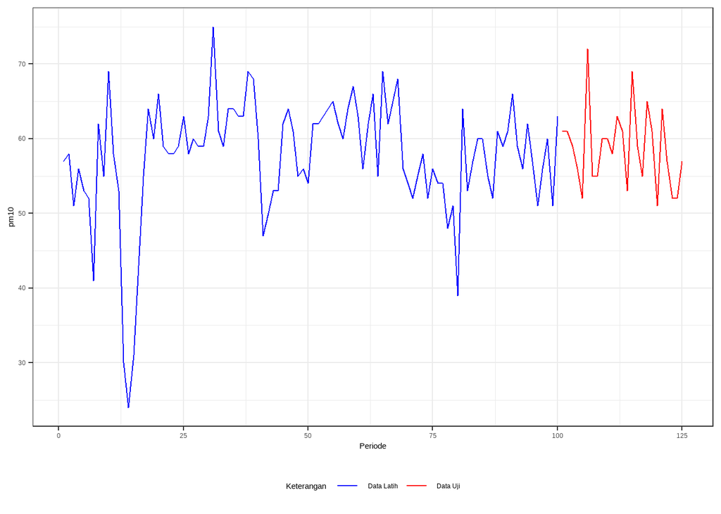

```r
# plot data latih dan data uji
ggplot() +
  geom_line(aes(x = 1:n_train, y = train.ts, col = "Data Latih")) +
  geom_line(aes(x = (n_train+1):n, y = test.ts, col = "Data Uji")) +
  labs(x = "Periode", y = target_col, color = "Keterangan") +
  scale_colour_manual(values = c("Data Latih" = "blue", "Data Uji" = "red")) +
  theme_bw() +
  theme(legend.position = "bottom")
```

# Single Moving Average (SMA)

## Pemulusan dan Peramalan dengan parameter `m=5`

```r
# parameter SMA
m <- 5

# hitung SMA
data.sma <- SMA(train.ts, n = m)

# forecast 1 periode ke depan
data.ramal <- c(NA, data.sma)

# forecast 24 periode ke depan sesuai data uji
data.gab.sma <- cbind(
  aktual    = c(ts_data),
  pemulusan = c(data.sma, rep(NA, length(test.ts))),
  ramalan   = c(data.ramal, rep(data.ramal[length(data.ramal)], length(test.ts)-1))
)

data.gab.sma
```

```
##        aktual pemulusan ramalan
##   [1,]     57        NA      NA
##   [2,]     58        NA      NA
##   [3,]     51        NA      NA
##   [4,]     56        NA      NA
##   [5,]     53      55.0      NA
##   [6,]     52      54.0    55.0
##   [7,]     41      50.6    54.0
##   [8,]     62      52.8    50.6
##   [9,]     55      52.6    52.8
##  [10,]     69      55.8    52.6
##  [11,]     58      57.0    55.8
##  [12,]     53      59.4    57.0
##  [13,]     30      53.0    59.4
##  [14,]     24      46.8    53.0
```

[output cut: 111 more lines]

## Plot SMA

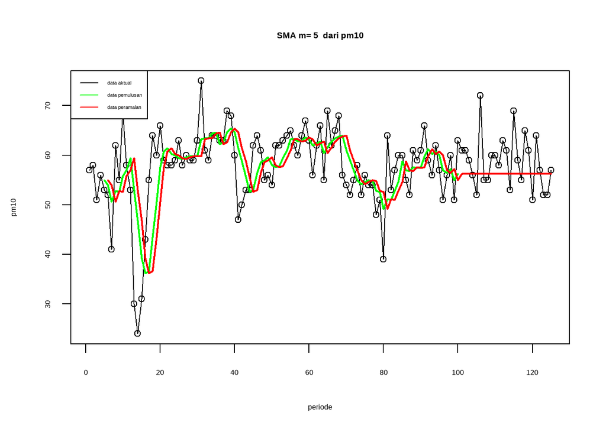

```r
# plot SMA
ts.plot(ts_data, xlab = "periode", ylab = target_col,
        main = paste("SMA m=", m, " dari", target_col))
points(ts_data)
lines(data.gab.sma[,2], col="green", lwd=2)
lines(data.gab.sma[,3], col="red", lwd=2)
legend("topleft",
       c("data aktual", "data pemulusan", "data peramalan"),
       lty = 1, col = c("black", "green", "red"), cex = 0.7)
```

## Akurasi Data Latih

```r
# hitung error data latih
error_train.sma <- train.ts - data.ramal[1:length(train.ts)]

# hitung akurasi mulai dari periode ke-(m+1)
SSE_train.sma  <- sum(error_train.sma[(m+1):length(train.ts)]^2)
MSE_train.sma  <- mean(error_train.sma[(m+1):length(train.ts)]^2)
MAPE_train.sma <- mean(abs(error_train.sma[(m+1):length(train.ts)] / train.ts[(m+1):length(train.ts)]) * 100)

akurasi_train.sma <- matrix(c(SSE_train.sma, MSE_train.sma, MAPE_train.sma),
                            nrow = 3, byrow = TRUE)
row.names(akurasi_train.sma) <- c("SSE", "MSE", "MAPE")
colnames(akurasi_train.sma) <- paste("Akurasi m =", m)
akurasi_train.sma
```

```
##      Akurasi m = 5
## SSE     6925.48000
## MSE       72.89979
## MAPE      11.93774
```

Karena MAPE > 10%, akurasi model pada data latih bisa dikategorikan cukup baik namun tidak sangat akurat

```r
# menghitung nilai keakuratan data uji
error_test.sma <- test.ts - data.gab.sma[(length(train.ts)+1):length(ts_data), 3]
SSE_test.sma  <- sum(error_test.sma^2)
MSE_test.sma  <- mean(error_test.sma^2)
MAPE_test.sma <- mean(abs(error_test.sma / test.ts) * 100)

akurasi_test.sma <- matrix(c(SSE_test.sma, MSE_test.sma, MAPE_test.sma),
                           nrow = 3, byrow = TRUE)
row.names(akurasi_test.sma) <- c("SSE", "MSE", "MAPE")
colnames(akurasi_test.sma) <- paste("Akurasi m =", m)
akurasi_test.sma
```

```
##      Akurasi m = 5
## SSE     833.800000
## MSE      33.352000
## MAPE      7.357041
```

Karena MAPE < 10%, akurasi model pada data uji dapat dikategorikan sangat baik.

# Double Moving Average (DMA)

## Pemulusan dan Peramalan dengan parameter `m=5`

```r
# parameter dma
m <- 5
h <- length(test.ts)

# SMA
SMA <- SMA(train.ts, n = m)

# DMA
DMA <- SMA(SMA, n = m)

At <- 2*SMA - DMA
Bt <- 2/(m-1) * (SMA - DMA)

# forecast 1 periode ke depan untuk data latih
data.ramal.dma <- c(NA, At + Bt)

# forecast h periode ke depan untuk data uji
forecast_h <- At[length(At)] + Bt[length(Bt)] * (1:h)

pemulusan1_full <- c(SMA, rep(NA, h))
pemulusan2_full <- c(DMA, rep(NA, h))
At_full        <- c(At, rep(NA, h))
Bt_full        <- c(Bt, rep(NA, h))
ramalan_full   <- c(data.ramal.dma, forecast_h[-1])

data.gab.dma <- cbind(
  aktual      = c(ts_data),
  pemulusan1  = pemulusan1_full,
  pemulusan2  = pemulusan2_full,
  At          = At_full,
  Bt          = Bt_full,
  ramalan     = ramalan_full
)

data.gab.dma
```

```
##        aktual pemulusan1 pemulusan2    At            Bt ramalan
##   [1,]     57         NA         NA    NA            NA      NA
##   [2,]     58         NA         NA    NA            NA      NA
##   [3,]     51         NA         NA    NA            NA      NA
##   [4,]     56         NA         NA    NA            NA      NA
##   [5,]     53       55.0         NA    NA            NA      NA
##   [6,]     52       54.0         NA    NA            NA      NA
##   [7,]     41       50.6         NA    NA            NA      NA
##   [8,]     62       52.8         NA    NA            NA      NA
##   [9,]     55       52.6      53.00 52.20 -2.000000e-01      NA
##  [10,]     69       55.8      53.16 58.44  1.320000e+00   52.00
##  [11,]     58       57.0      53.76 60.24  1.620000e+00   59.76
##  [12,]     53       59.4      55.52 63.28  1.940000e+00   61.86
##  [13,]     30       53.0      55.56 50.44 -1.280000e+00   65.22
##  [14,]     24       46.8      54.40 39.20 -3.800000e+00   49.16
```

[output cut: 111 more lines]

## Plot DMA

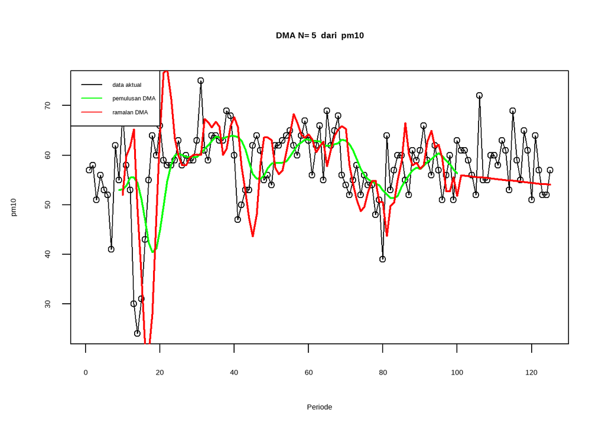

```r
# plot dma
ts.plot(ts_data, xlab="Periode", ylab=target_col,
        main=paste("DMA N=", m, " dari ", target_col))
points(ts_data)
lines(data.gab.dma[,3], col="green", lwd=2)  # pemulusan kedua
lines(data.gab.dma[,6], col="red", lwd=2)    # ramalan
legend("topleft", c("data aktual","pemulusan DMA","ramalan DMA"),
       lty=1, col=c("black","green","red"), cex=0.8)
```

## Akurasi Data Latih

```r
error_train.dma <- train.ts - data.ramal.dma[1:length(train.ts)]
SSE_train.dma <- sum(error_train.dma[(m*2):length(train.ts)]^2)
MSE_train.dma <- mean(error_train.dma[(m*2):length(train.ts)]^2)
MAPE_train.dma <- mean(abs(error_train.dma[(m*2):length(train.ts)] / train.ts[(m*2):length(train.ts)])*100)

akurasi_train.dma <- matrix(c(SSE_train.dma, MSE_train.dma, MAPE_train.dma),
                            nrow=3, byrow=TRUE)
rownames(akurasi_train.dma) <- c("SSE","MSE","MAPE")
colnames(akurasi_train.dma) <- paste("Akurasi m =", m)
akurasi_train.dma
```

```
##      Akurasi m = 5
## SSE    10226.07800
## MSE      112.37448
## MAPE      14.33238
```

## Akurasi Data Uji

```r
error_test.dma <- test.ts - data.gab.dma[(length(train.ts)+1):(length(train.ts)+h),6]
SSE_test.dma <- sum(error_test.dma^2)
MSE_test.dma <- mean(error_test.dma^2)
MAPE_test.dma <- mean(abs(error_test.dma / test.ts) * 100)

akurasi_test.dma <- matrix(c(SSE_test.dma, MSE_test.dma, MAPE_test.dma),
                           nrow=3, byrow=TRUE)
rownames(akurasi_test.dma) <- c("SSE","MSE","MAPE")
colnames(akurasi_test.dma) <- paste("Akurasi m =", m)
akurasi_test.dma
```

```
##      Akurasi m = 5
## SSE     999.880000
## MSE      39.995200
## MAPE      7.826639
```

Karena nilai MAPE < 10%, sehingga akurasi model DMA pada data uji dikategorikan sangat baik

Pada data latih, metode SMA lebih baik dibandingkan metode DMA, karena nilai MAPE-nya lebih rendah, menunjukkan peramalan SMA lebih dekat dengan data aktual. Begitu juga pada data uji, metode SMA tetap lebih baik dibandingkan DMA, dengan MAPE lebih kecil sehingga peramalan SMA lebih akurat dalam menangkap pola data dibanding DMA.

# Single Exponential Smoothing

## Pemulusan dan Peramalan dengan SES alpha optimum

### Fungsi SES

```r
# cara 1 (fungsi ses)
data.ses <- ses(train.ts, h = length(test.ts), alpha = NULL)
data.ses
```

```
##     Point Forecast    Lo 80    Hi 80    Lo 95     Hi 95
## 101       60.08835 50.98156 69.19514 46.16072  74.01598
## 102       60.08835 48.96575 71.21095 43.07780  77.09889
## 103       60.08835 47.26295 72.91374 40.47360  79.70310
## 104       60.08835 45.76112 74.41557 38.17675  81.99995
## 105       60.08835 44.40243 75.77426 36.09881  84.07789
## 106       60.08835 43.15239 77.02430 34.18704  85.98965
## 107       60.08835 41.98848 78.18821 32.40699  87.76970
## 108       60.08835 40.89502 79.28167 30.73469  89.44200
## 109       60.08835 39.86059 80.31611 29.15266  91.02404
## 110       60.08835 38.87654 81.30016 27.64768  92.52901
## 111       60.08835 37.93616 82.24054 26.20950  93.96720
## 112       60.08835 37.03410 83.14259 24.82993  95.34677
## 113       60.08835 36.16604 84.01065 23.50234  96.67435
## 114       60.08835 35.32839 84.84830 22.22127  97.95543
## 115       60.08835 34.51817 85.65852 20.98214  99.19455
## 116       60.08835 33.73285 86.44385 19.78109 100.39561
## 117       60.08835 32.97025 87.20644 18.61480 101.56189
## 118       60.08835 32.22853 87.94817 17.48043 102.69627
## 119       60.08835 31.50604 88.67065 16.37548 103.80121
## 120       60.08835 30.80137 89.37532 15.29779 104.87891
## 121       60.08835 30.11327 90.06343 14.24542 105.93127
## 122       60.08835 29.44061 90.73609 13.21667 106.96002
## 123       60.08835 28.78240 91.39430 12.21003 107.96667
## 124       60.08835 28.13774 92.03895 11.22411 108.95258
## 125       60.08835 27.50584 92.67085 10.25770 109.91899
```

### Fungsi HoltWinters

```r
data.sesh <- HoltWinters(train.ts, gamma = FALSE, beta = FALSE, alpha = NULL)
data.sesh
```

```
## Holt-Winters exponential smoothing without trend and without seasonal component.
##
## Call:
## HoltWinters(x = train.ts, alpha = NULL, beta = FALSE, gamma = FALSE)
##
## Smoothing parameters:
##  alpha: 0.7014047
##  beta : FALSE
##  gamma: FALSE
##
## Coefficients:
##       [,1]
## a 60.08986
```

```r
data.ramalsesh <- forecast(data.sesh, h = length(test.ts))
data.ramalsesh
```

```
##     Point Forecast    Lo 80    Hi 80    Lo 95     Hi 95
## 101       60.08986 50.98320 69.19652 46.16243  74.01729
## 102       60.08986 48.96642 71.21329 43.07803  77.10168
## 103       60.08986 47.26292 72.91680 40.47275  79.70697
## 104       60.08986 45.76052 74.41919 38.17503  82.00469
## 105       60.08986 44.40134 75.77837 36.09635  84.08337
## 106       60.08986 43.15088 77.02884 34.18393  85.99579
## 107       60.08986 41.98658 78.19313 32.40329  87.77643
## 108       60.08986 40.89277 79.28694 30.73045  89.44927
## 109       60.08986 39.85801 80.32171 29.14792  91.03180
## 110       60.08986 38.87366 81.30606 27.64248  92.53724
## 111       60.08986 37.93299 82.24673 26.20385  93.97586
## 112       60.08986 37.03067 83.14905 24.82387  95.35585
## 113       60.08986 36.16234 84.01737 23.49588  96.68383
## 114       60.08986 35.32445 84.85527 22.21443  97.96528
## 115       60.08986 34.51399 85.66573 20.97494  99.20477
## 116       60.08986 33.72844 86.45128 19.77354 100.40617
## 117       60.08986 32.96562 87.21409 18.60692 101.57280
## 118       60.08986 32.22368 87.95603 17.47222 102.70749
## 119       60.08986 31.50099 88.67872 16.36696 103.81275
## 120       60.08986 30.79612 89.38359 15.28896 104.89076
## 121       60.08986 30.10782 90.07189 14.23629 105.94342
## 122       60.08986 29.43497 90.74474 13.20726 106.97246
## 123       60.08986 28.77658 91.40314 12.20033 107.97939
## 124       60.08986 28.13174 92.04797 11.21414 108.96557
## 125       60.08986 27.49967 92.68005 10.24746 109.93225
```

## Plot SES

### Fungsi SES

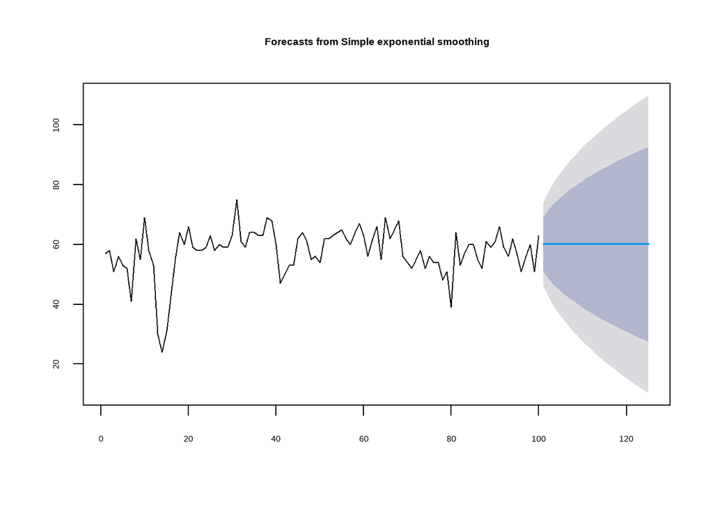

```r
# plot ses
plot(data.ses)
```

### Fungsi HoltWinters

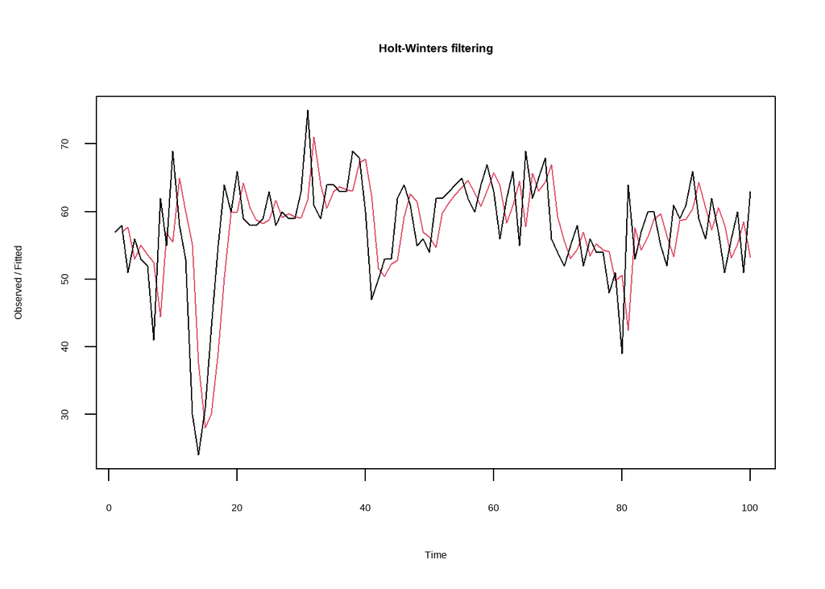

```r
# plot holtwinters
plot(data.sesh)
```

## Akurasi Data Latih

### Data Latih SES

```r
SSE_train_ses  <- sum((train.ts - data.ses$fitted)^2, na.rm = TRUE)
MSE_train_ses  <- SSE_train_ses / length(train.ts)
RMSE_train_ses <- sqrt(MSE_train_ses)

akurasitrain_ses <- matrix(c(SSE_train_ses, MSE_train_ses, RMSE_train_ses),
                           ncol = 1,
                           dimnames = list(c("SSE","MSE","RMSE"),
                                           "Train SES alpha optimum"))
akurasitrain_ses
```

```
##      Train SES alpha optimum
## SSE              4948.623901
## MSE                49.486239
## RMSE                7.034646
```

### Data Latih HoltWinters

```r
SSE_train_sesh  <- data.sesh$SSE
MSE_train_sesh  <- SSE_train_sesh / length(train.ts)
RMSE_train_sesh <- sqrt(MSE_train_sesh)

akurasitrain_sesh <- matrix(c(SSE_train_sesh, MSE_train_sesh, RMSE_train_sesh),
                            ncol = 1,
                            dimnames = list(c("SSE","MSE","RMSE"),
                                            "Train HoltWinters alpha optimum"))
akurasitrain_sesh
```

```
##      Train HoltWinters alpha optimum
## SSE                      4948.678200
## MSE                        49.486782
## RMSE                        7.034684
```

## Akurasi Data Uji

### Data Uji SES

```r
err_test_ses  <- as.numeric(data.ses$mean) - as.numeric(test.ts)
SSE_test_ses  <- sum(err_test_ses^2, na.rm = TRUE)
MSE_test_ses  <- mean(err_test_ses^2, na.rm = TRUE)
RMSE_test_ses <- sqrt(MSE_test_ses)

akurasitest_ses <- matrix(c(SSE_test_ses, MSE_test_ses, RMSE_test_ses),
                          ncol = 1,
                          dimnames = list(c("SSE","MSE","RMSE"),
                                          "Test SES alpha optimum"))
akurasitest_ses
```

```
##      Test SES alpha optimum
## SSE              721.849335
## MSE               28.873973
## RMSE               5.373451
```

### Data Uji HoltWinters

```r
err_test_sesh  <- as.numeric(data.ramalsesh$mean) - as.numeric(test.ts)
SSE_test_sesh  <- sum(err_test_sesh^2, na.rm = TRUE)
MSE_test_sesh  <- mean(err_test_sesh^2, na.rm = TRUE)
RMSE_test_sesh <- sqrt(MSE_test_sesh)

akurasitest_sesh <- matrix(c(SSE_test_sesh, MSE_test_sesh, RMSE_test_sesh),
                           ncol = 1,
                           dimnames = list(c("SSE","MSE","RMSE"),
                                           "Test HoltWinters alpha optimum"))
akurasitest_sesh
```

```
##      Test HoltWinters alpha optimum
## SSE                      721.952751
## MSE                       28.878110
## RMSE                       5.373836
```

# Double Exponential Smoothing

## Pemulusan dan Peramalan dengan DES alpha dan beta optimum

```r
data.des <- holt(train.ts, h = length(test.ts), alpha = NULL, beta = NULL, damped = FALSE)
data.des
```

```
##     Point Forecast    Lo 80    Hi 80    Lo 95     Hi 95
## 101       60.13364 50.91773 69.34955 46.03912  74.22816
## 102       60.18257 48.94246 71.42267 42.99231  77.37282
## 103       60.23149 47.27932 73.18365 40.42286  80.04012
## 104       60.28041 45.81704 74.74379 38.16059  82.40023
## 105       60.32934 44.49799 76.16069 36.11737  84.54130
## 106       60.37826 43.28774 77.46878 34.24056  86.51596
## 107       60.42718 42.16377 78.69059 32.49571  88.35866
## 108       60.47611 41.11041 79.84180 30.85883  90.09339
## 109       60.52503 40.11620 80.93386 29.31242  91.73764
## 110       60.57395 39.17251 81.97540 27.84326  93.30465
## 111       60.62288 38.27258 82.97317 26.44105  94.80470
## 112       60.67180 37.41108 83.93252 25.09760  96.24601
## 113       60.72073 36.58364 84.85781 23.80624  97.63521
## 114       60.76965 35.78669 85.75260 22.56152  98.97778
## 115       60.81857 35.01723 86.61991 21.35883 100.27832
## 116       60.86750 34.27272 87.46228 20.19429 101.54070
## 117       60.91642 33.55098 88.28186 19.06459 102.76825
## 118       60.96534 32.85015 89.08054 17.96686 103.96382
## 119       61.01427 32.16859 89.85994 16.89862 105.12992
## 120       61.06319 31.50488 90.62150 15.85766 106.26872
## 121       61.11211 30.85776 91.36647 14.84207 107.38216
## 122       61.16104 30.22610 92.09598 13.85013 108.47194
## 123       61.20996 29.60890 92.81102 12.88032 109.53961
## 124       61.25888 29.00528 93.51249 11.93125 110.58652
## 125       61.30781 28.41442 94.20120 11.00171 111.61391
```

## Plot DES

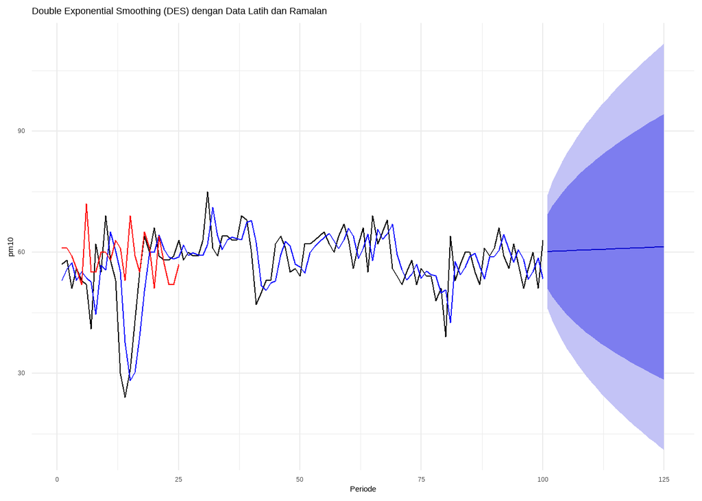

```r
autoplot(data.des) +
  autolayer(fitted(data.des), series="Fitted", color="blue") +
  autolayer(test.ts, series="Actual Test", color="red") +
  ylab(target_col) +
  xlab("Periode") +
  ggtitle("Double Exponential Smoothing (DES) dengan Data Latih dan Ramalan") +
  theme_minimal()
```

## Akurasi Data Latih

```r
SSE_train_des  <- sum((train.ts - fitted(data.des))^2, na.rm = TRUE)
MSE_train_des  <- SSE_train_des / length(train.ts)
RMSE_train_des <- sqrt(MSE_train_des)

akurasitrain_des <- matrix(c(SSE_train_des, MSE_train_des, RMSE_train_des),
                           ncol = 1,
                           dimnames = list(c("SSE","MSE","RMSE"),
                                           "Train DES alpha/beta optimum"))
akurasitrain_des
```

```
##      Train DES alpha/beta optimum
## SSE                   4964.500349
## MSE                     49.645003
## RMSE                     7.045921
```

## Akurasi Data Uji

```r
err_test_des  <- as.numeric(data.des$mean) - as.numeric(test.ts)
SSE_test_des  <- sum(err_test_des^2, na.rm = TRUE)
MSE_test_des  <- mean(err_test_des^2, na.rm = TRUE)
RMSE_test_des <- sqrt(MSE_test_des)

akurasitest_des <- matrix(c(SSE_test_des, MSE_test_des, RMSE_test_des),
                          ncol = 1,
                          dimnames = list(c("SSE","MSE","RMSE"),
                                          "Test DES alpha/beta optimum"))
akurasitest_des
```

```
##      Test DES alpha/beta optimum
## SSE                   796.227985
## MSE                    31.849119
## RMSE                    5.643502
```

# Perbandingan Hasil Peramalan (MSE)

```r
# Gabungkan MSE data latih dan data uji
perbandinganmse <- rbind(
  c(akurasi_train.sma[2,1], akurasi_train.dma[2,1], akurasitrain_ses[2,1], akurasitrain_des[2,1]),
  c(akurasi_test.sma[2,1], akurasi_test.dma[2,1], akurasitest_ses[2,1], akurasitest_des[2,1])
)

# Beri nama baris dan kolom
rownames(perbandinganmse) <- c("MSE Data Train", "MSE Data Test")
colnames(perbandinganmse) <- c("SMA n=5", "DMA n=5", "SES alpha optimum",  "DES alpha & beta optimum")

# Tampilkan tabel
perbandinganmse
```

```
##                 SMA n=5  DMA n=5 SES alpha optimum DES alpha & beta optimum
## MSE Data Train 72.89979 112.3745          49.48624                 49.64500
## MSE Data Test  33.35200  39.9952          28.87397                 31.84912
```

SES dan DES dengan parameter optimum memberikan MSE paling rendah dibanding SMA dan DMA, artinya kedua metode ini lebih akurat untuk meramalkan data ini.